# Pneumonia Detection using CNN and Object Detection

# Step 2: Apply Transfer Learning model for classification

```python
earlyStoppingCallback = EarlyStopping(monitor='val_loss', patience=3)
```

### Step 2.1: VGG16

```python
from tensorflow.keras.applications import VGG16
from tensorflow.keras.layers import Input

#Load the VGG model
img_input = (32, 32, 3)
vgg_conv = VGG16(weights='imagenet', include_top=False, input_shape=img_input)

# Freeze all the layers except for the last few layers:
for layer in vgg_conv.layers[:-5]:
    layer.trainable = False
```

```
Downloading data from https://storage.googleapis.com/tensorflow/keras-applications/vgg16/vgg16_weights_tf_dim_ordering_tf_kernels_notop.h5
```

```python
vgg_conv.summary()
```

```
Model: "vgg16"
_________________________________________________________________
 Layer (type)                Output Shape              Param #
=================================================================
 input_3 (InputLayer)        [(None, 32, 32, 3)]       0

 block1_conv1 (Conv2D)       (None, 32, 32, 64)        1792

 block1_conv2 (Conv2D)       (None, 32, 32, 64)        36928

 block1_pool (MaxPooling2D)  (None, 16, 16, 64)        0

 block2_conv1 (Conv2D)       (None, 16, 16, 128)       73856

 block2_conv2 (Conv2D)       (None, 16, 16, 128)       147584

 block2_pool (MaxPooling2D)  (None, 8, 8, 128)         0

 block3_conv1 (Conv2D)       (None, 8, 8, 256)         295168

 block3_conv2 (Conv2D)       (None, 8, 8, 256)         590080

 block3_conv3 (Conv2D)       (None, 8, 8, 256)         590080

 block3_pool (MaxPooling2D)  (None, 4, 4, 256)         0

 block4_conv1 (Conv2D)       (None, 4, 4, 512)         1180160

 block4_conv2 (Conv2D)       (None, 4, 4, 512)         2359808

 block4_conv3 (Conv2D)       (None, 4, 4, 512)         2359808

 block4_pool (MaxPooling2D)  (None, 2, 2, 512)         0

 block5_conv1 (Conv2D)       (None, 2, 2, 512)         2359808

 block5_conv2 (Conv2D)       (None, 2, 2, 512)         2359808

 block5_conv3 (Conv2D)       (None, 2, 2, 512)         2359808

 block5_pool (MaxPooling2D)  (None, 1, 1, 512)         0

=================================================================
Total params: 14,714,688
Trainable params: 7,079,424
Non-trainable params: 7,635,264
_________________________________________________________________
```

```python
# Create the model
model_vgg = Sequential()

# Add the vgg convolutional base model
model_vgg.add(vgg_conv)

# Add new layers
model_vgg.add(Flatten())
model_vgg.add(Dense(512, activation='relu'))
model_vgg.add(Dropout(0.5))
model_vgg.add(Dense(256, activation='relu'))
model_vgg.add(Dropout(0.5))
model_vgg.add(Dense(128, activation='relu'))
model_vgg.add(Dropout(0.3))
model_vgg.add(Dense(128, activation='relu'))
model_vgg.add(Dropout(0.3))

# Output layer
model_vgg.add(Dense(3, activation='softmax'))
model_vgg.summary()
```

```
Model: "sequential_2"
_________________________________________________________________
 Layer (type)                Output Shape              Param #
=================================================================
 vgg16 (Functional)          (None, 1, 1, 512)         14714688

 flatten_2 (Flatten)         (None, 512)               0

 dense_4 (Dense)             (None, 512)               262656

 dropout_3 (Dropout)         (None, 512)               0

 dense_5 (Dense)             (None, 256)               131328

 dropout_4 (Dropout)         (None, 256)               0

 dense_6 (Dense)             (None, 128)               32896

 dropout_5 (Dropout)         (None, 128)               0

 dense_7 (Dense)             (None, 128)               16512

 dropout_6 (Dropout)         (None, 128)               0

 dense_8 (Dense)             (None, 3)                 387

=================================================================
Total params: 15,158,467
Trainable params: 7,523,203
Non-trainable params: 7,635,264
_________________________________________________________________
```

```python
# initialize the model and optimizer
sgd= optimizers.SGD()
model_vgg.compile(loss="sparse_categorical_crossentropy", optimizer=sgd, metrics=["accuracy"])
vgg_default_history = model_vgg.fit(X_train, y_train, epochs = 20, batch_size=BATCH_SIZE,
                        validation_data=(X_test, y_test), callbacks=[earlyStoppingCallback])
```

```python
eval_df.loc[len(eval_df.index)] = ['vgg_model_default',mean(vgg_default_history.history['val_loss']), mean(vgg_default_history.history['val_accuracy']), "Vegg Model"]
```

##### The loss and validation loss is coming as NaN - it means the Learning rate and/or momentum needs to be fine tunned.

```python
sgd= optimizers.SGD(learning_rate= 0.1,momentum=.99)
model_vgg.compile(loss="sparse_categorical_crossentropy", optimizer=sgd, metrics=["accuracy"])
earlyStoppingCallback = EarlyStopping(monitor='val_loss', patience=3)
vgg_history = model_vgg.fit(X_train, y_train, epochs = 20, batch_size=BATCH_SIZE,
                        validation_data=(X_test, y_test), callbacks=[earlyStoppingCallback])
```

```python
eval_df.loc[len(eval_df.index)] = ['vgg_lr_mom',mean(vgg_history.history['val_loss']), mean(vgg_history.history['val_accuracy']), "Vegg Model with LR as 0.1 and Mom as .99"]
```

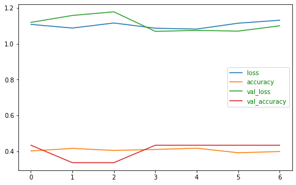

```python
pd.DataFrame(vgg_history.history).plot(figsize=(8,5))
plt.show()
```

##### With the LR=0.1 and Momentum = 0.99 we are getting below average result.

### Step 2.2: Using ResNet50

```python
from tensorflow.keras.applications.resnet50 import ResNet50

res_model = Sequential()

res = ResNet50(include_top=False, weights='imagenet',input_shape = (32, 32, 3))

print(res.summary())

res_model.add(res)

# Add new layers
res_model.add(Flatten())
res_model.add(Dense(512, activation='relu'))
res_model.add(Dropout(0.5))
res_model.add(Dense(256, activation='relu'))
res_model.add(Dropout(0.5))
res_model.add(Dense(128, activation='relu'))
res_model.add(Dropout(0.3))
# Output layer
res_model.add(Dense(3, activation='softmax'))

res_model.summary()
```

```
Model: "resnet50"
__________________________________________________________________________________________________
 Layer (type)                   Output Shape         Param #     Connected to
==================================================================================================
 input_6 (InputLayer)           [(None, 32, 32, 3)]  0           []

 conv1_pad (ZeroPadding2D)      (None, 38, 38, 3)    0           ['input_6[0][0]']

 conv1_conv (Conv2D)            (None, 16, 16, 64)   9472        ['conv1_pad[0][0]']

 conv1_bn (BatchNormalization)  (None, 16, 16, 64)   256         ['conv1_conv[0][0]']

 conv1_relu (Activation)        (None, 16, 16, 64)   0           ['conv1_bn[0][0]']

 pool1_pad (ZeroPadding2D)      (None, 18, 18, 64)   0           ['conv1_relu[0][0]']

 pool1_pool (MaxPooling2D)      (None, 8, 8, 64)     0           ['pool1_pad[0][0]']

 conv2_block1_1_conv (Conv2D)   (None, 8, 8, 64)     4160        ['pool1_pool[0][0]']

 conv2_block1_1_bn (BatchNormal  (None, 8, 8, 64)    256         ['conv2_block1_1_conv[0][0]']
 ization)

 conv2_block1_1_relu (Activatio  (None, 8, 8, 64)    0           ['conv2_block1_1_bn[0][0]']
 n)

 conv2_block1_2_conv (Conv2D)   (None, 8, 8, 64)     36928       ['conv2_block1_1_relu[0][0]']

 conv2_block1_2_bn (BatchNormal  (None, 8, 8, 64)    256         ['conv2_block1_2_conv[0][0]']
 ization)

 conv2_block1_2_relu (Activatio  (None, 8, 8, 64)    0           ['conv2_block1_2_bn[0][0]']
 n)

 conv2_block1_0_conv (Conv2D)   (None, 8, 8, 256)    16640       ['pool1_pool[0][0]']

 conv2_block1_3_conv (Conv2D)   (None, 8, 8, 256)    16640       ['conv2_block1_2_relu[0][0]']

 conv2_block1_0_bn (BatchNormal  (None, 8, 8, 256)   1024        ['conv2_block1_0_conv[0][0]']
 ization)
```

[output cut: 432 more lines]

```
 dense_18 (Dense)            (None, 256)               131328

 dropout_14 (Dropout)        (None, 256)               0

 dense_19 (Dense)            (None, 128)               32896

 dropout_15 (Dropout)        (None, 128)               0

 dense_20 (Dense)            (None, 3)                 387

=================================================================
Total params: 24,801,411
Trainable params: 24,748,291
Non-trainable params: 53,120
_________________________________________________________________
```

```python
res_model.compile(loss='sparse_categorical_crossentropy',optimizer=optimizers.SGD(), metrics=['accuracy'])
```

```python
from tensorflow.keras.applications.resnet50 import preprocess_input
earlyStoppingCallback = EarlyStopping(monitor='val_loss', patience=3)
res_history = res_model.fit(preprocess_input(X_train), y_train, epochs = 20, batch_size=BATCH_SIZE,
                            validation_data=(preprocess_input(X_test), y_test), callbacks=[earlyStoppingCallback])
```

```python
eval_df.loc[len(eval_df.index)] = ['ResNet50_default',mean(res_history.history['val_loss']), mean(res_history.history['val_accuracy']), "ResNet50"]
```

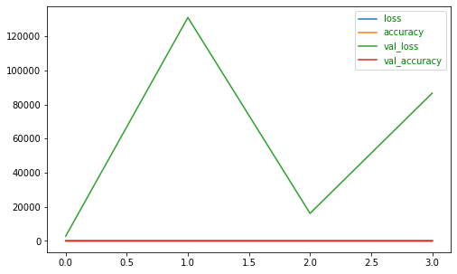

```python
pd.DataFrame(res_history.history).plot(figsize=(8,5))
plt.show()
```

##### Very high Validation loss - Does it mean model is overfitting or the RestNET is not suitable for this data because RestNet is using lot of parameter. TODO - Check more

### Step 2.3: Using DenseNet169

```python
from tensorflow.keras.applications  import DenseNet169
dense = DenseNet169(input_shape = (32, 32, 3),
                                include_top = False,
                                weights='imagenet')
model_dense= Sequential()
model_dense.add(dense)

model_dense.add(Flatten())

model_dense.add(Dense(512,activation=('relu')))
model_dense.add(Dropout(.5))
model_dense.add(BatchNormalization())
model_dense.add(Dense(256,activation=('relu')))
model_dense.add(Dropout(.3))
model_dense.add(BatchNormalization())
model_dense.add(Dense(128,activation=('relu')))
model_dense.add(Dropout(.3))
model_dense.add(Dense(128,activation=('relu')))
model_dense.add(Dropout(.3))

# Output layer
model_dense.add(Dense(3,activation=('softmax')))

#Check final model summary
model_dense.summary()
```

```
Downloading data from https://storage.googleapis.com/tensorflow/keras-applications/densenet/densenet169_weights_tf_dim_ordering_tf_kernels_notop.h5
Model: "sequential_7"
_________________________________________________________________
 Layer (type)                Output Shape              Param #
=================================================================
 densenet169 (Functional)    (None, 1, 1, 1664)        12642880

 flatten_6 (Flatten)         (None, 1664)              0

 dense_21 (Dense)            (None, 512)               852480

 dropout_16 (Dropout)        (None, 512)               0

 batch_normalization_7 (Batc  (None, 512)              2048
 hNormalization)

 dense_22 (Dense)            (None, 256)               131328

 dropout_17 (Dropout)        (None, 256)               0

 batch_normalization_8 (Batc  (None, 256)              1024
 hNormalization)

 dense_23 (Dense)            (None, 128)               32896

 dropout_18 (Dropout)        (None, 128)               0

 dense_24 (Dense)            (None, 128)               16512

 dropout_19 (Dropout)        (None, 128)               0

 dense_25 (Dense)            (None, 3)                 387

=================================================================
Total params: 13,679,555
Trainable params: 13,519,619
Non-trainable params: 159,936
_________________________________________________________________
```

```python
model_dense.compile(optimizer=optimizers.SGD(),loss='sparse_categorical_crossentropy',metrics=['accuracy'])
```

```python
dense_history = model_dense.fit(X_train, y_train, epochs = 20, batch_size=32,
                        validation_data=(X_test, y_test), callbacks=[earlyStoppingCallback])
```

```python
eval_df.loc[len(eval_df.index)] = ['DenseNet169',mean(dense_history.history['val_loss']), mean(dense_history.history['val_accuracy']), "DenseNet169 Default"]
```

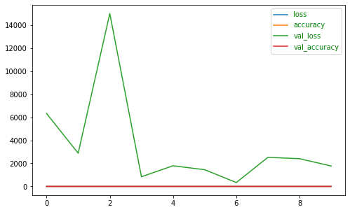

```python
pd.DataFrame(dense_history.history).plot(figsize=(8,5))
plt.show()
```

##### Dense net as well showing high validation loss. Is it because not having well balanced data. Let us experiement with down sampled data

```python
dense_history_down = model_dense.fit(down_X_train, down_y_train, epochs = 20, batch_size=32,
                        validation_data=(down_X_test, down_y_test), callbacks=[earlyStoppingCallback])
```

```python
eval_df.loc[len(eval_df.index)] = ['DenseNet169_downsample',mean(dense_history_down.history['val_loss']), mean(dense_history_down.history['val_accuracy']), "DenseNet169 Default with downsample data"]
```

##### We should check with more epoch on downsample data

```python
dense_history_down = model_dense.fit(down_X_train, down_y_train, epochs = 20, batch_size=32,
                        validation_data=(down_X_test, down_y_test))
```

```python
eval_df.loc[len(eval_df.index)] = ['DenseNet169_downsample_epoch',mean(dense_history_down.history['val_loss']), mean(dense_history_down.history['val_accuracy']), "DenseNet169 Default with downsample data with 20 number of epoch"]
```

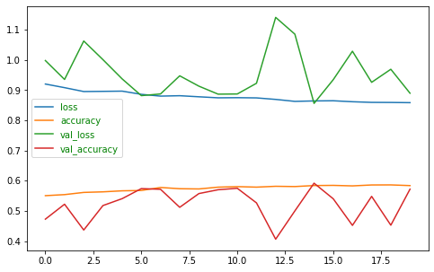

```python
pd.DataFrame(dense_history_down.history).plot(figsize=(8,5))
plt.show()
```

```python
model_dense.compile(optimizer=optimizers.SGD(momentum=0.99),loss='sparse_categorical_crossentropy',metrics=['accuracy'])
dense_history_down_mom = model_dense.fit(down_X_train, down_y_train, epochs = 25, batch_size=100,
                        validation_data=(down_X_test, down_y_test))
```

```python
eval_df.loc[len(eval_df.index)] = ['DenseNet169_downsample_epoch_mom',mean(dense_history_down_mom.history['val_loss']), mean(dense_history_down_mom.history['val_accuracy']), "DenseNet169 Default with downsample data with 20 number of epoch and .99 momentum"]
```

### 2.4 Mobile Net

```python
from tensorflow.keras.applications import MobileNet

mobile = MobileNet(include_top=False, weights='imagenet',input_shape=(32,32,3), classes=3)
```

```
WARNING:tensorflow:`input_shape` is undefined or non-square, or `rows` is not in [128, 160, 192, 224]. Weights for input shape (224, 224) will be loaded as the default.
```

```
WARNING:tensorflow:`input_shape` is undefined or non-square, or `rows` is not in [128, 160, 192, 224]. Weights for input shape (224, 224) will be loaded as the default.
```

```
Downloading data from https://storage.googleapis.com/tensorflow/keras-applications/mobilenet/mobilenet_1_0_224_tf_no_top.h5
```

```python
model_mobile= Sequential()

#Add the base model
model_mobile.add(mobile)
model_mobile.add(Dropout(0.5))
model_mobile.add(Flatten())

model_mobile.add(Dense(512,activation=('relu')))
model_mobile.add(Dropout(.5)) #Adding a dropout layer that will randomly drop 50% of the weights
model_mobile.add(Dense(256,activation=('relu')))
model_mobile.add(Dropout(.3))
model_mobile.add(Dense(128,activation=('relu')))
model_mobile.add(Dropout(.3))

# Output layer
model_mobile.add(Dense(3,activation=('softmax')))
#Check final model summary
model_mobile.summary()
```

```
Model: "sequential_8"
_________________________________________________________________
 Layer (type)                Output Shape              Param #
=================================================================
 mobilenet_1.00_224 (Functio  (None, 1, 1, 1024)       3228864
 nal)

 dropout_20 (Dropout)        (None, 1, 1, 1024)        0

 flatten_7 (Flatten)         (None, 1024)              0

 dense_26 (Dense)            (None, 512)               524800

 dropout_21 (Dropout)        (None, 512)               0

 dense_27 (Dense)            (None, 256)               131328

 dropout_22 (Dropout)        (None, 256)               0

 dense_28 (Dense)            (None, 128)               32896

 dropout_23 (Dropout)        (None, 128)               0

 dense_29 (Dense)            (None, 3)                 387

=================================================================
Total params: 3,918,275
Trainable params: 3,896,387
Non-trainable params: 21,888
_________________________________________________________________
```

```python
model_mobile.compile(optimizer=optimizers.SGD(),loss='sparse_categorical_crossentropy',metrics=['accuracy'])
```

```python
mobile_history = model_mobile.fit(X_train, y_train, epochs = 20, batch_size=32,
                        validation_data=(X_test, y_test), callbacks=[earlyStoppingCallback])
```

```python
eval_df.loc[len(eval_df.index)] = ['MobileNet_SDG',mean(mobile_history.history['val_loss']), mean(mobile_history.history['val_accuracy']), "MobileNet with SDG Optimizer"]
```

```python
model_mobile.compile(optimizer=optimizers.Adam(),loss='sparse_categorical_crossentropy',metrics=['accuracy'])
```

```python
mobile_history_2 = model_mobile.fit(X_train, y_train, epochs = 20, batch_size=32,
                        validation_data=(X_test, y_test), callbacks=[earlyStoppingCallback])
```

```python
eval_df.loc[len(eval_df.index)] = ['MobileNet_Adam',mean(mobile_history_2.history['val_loss']), mean(mobile_history_2.history['val_accuracy']), "MobileNet with Adam Optimizer"]
```

##### Mobilenet produces below average accuracy

### Summary

```python
eval_df
```

|  | model_name | loss | accuracy | description |
| --- | --- | --- | --- | --- |
| 0 | model_1 | 1.238485 | 0.502123 | Basic CNN with 3 hidden layer without dropout |
| 1 | model_2 | 0.744067 | 0.662004 | Basic CNN with 7 hidden layer, dropout |
| 2 | model_3 | 0.000000 | 0.000000 | Refer Step - 1.2.1 |
| 3 | model_4 | 15340.288544 | 0.290746 | Model2 with Adam optimizer |
| 4 | vgg_model_default | NaN | 0.230077 | Vegg Model |
| 5 | vgg_lr_mom | 1.109797 | 0.405838 | Vegg Model with LR as 0.1 and Mom as .99 |
| 6 | ResNet50_default | 59150.973267 | 0.360605 | ResNet50 |
| 7 | DenseNet169 | 3531.678098 | 0.365476 | DenseNet169 Default |
| 8 | DenseNet169_downsample | 0.954320 | 0.521890 | DenseNet169 Default with downsample data |
| 9 | DenseNet169_downsample_epoch | 0.954320 | 0.521890 | DenseNet169 Default with downsample data with ... |
| 10 | DenseNet169_downsample_epoch_mom | 0.853227 | 0.592672 | DenseNet169 Default with downsample data with ... |
| 11 | MobileNet_SDG | 1.624691 | 0.352486 | MobileNet with SDG Optimizer |
| 12 | MobileNet_Adam | 27.065041 | 0.336248 | MobileNet with Adam Optimizer |

#### Model_1 is something that we carried from milestone one with very limited number of hidden layer which was giving above 50% accuracy.

#### Model_2 is an updated version of model_1 which was giving 66% accuracy with SDG Optimizer.

#### Model_3 is where we kept model_2 as base and tried to find best learning rate and momentum further to optimize. The initial plan was to get the best value with increased accuracy and then try more number of epoch. The learning rate we used was [0.00001, 0.0001, 0.1] and momentum we tried was [0.5, 0.9, 0.99]. We did not get a best value though learning rate 0.1 was showing some improvement.

#### Model_4 is updated version of model_2 with Adam optimizer

#### We then tried some transfer learning technique using Keras VGG, RestNET, DenseNet and MoileNet

#### If you see the report - the customized DesnNet was showing good improvement from base model however it is still under 60% accuracy. We should be able to optimize this further with more number of retrying using Keras Tuner kind of packages.

#### I have stopped with this assuming Model_2 as Best Model as it took more than a week time to run in my laptop with lots of hiccups here and there.

#### Following is saved, Model_2, and Last Dataframe with image details.

```python
import pickle
```

```python
pickle.dump(model2, open('milestone_2_best_model.sav', 'wb'))
data.to_csv('first_milestone_df.csv')
```

[output not shown]

[output cut: 111 more lines]

[output not shown]